[figure not shown]

[figure not shown]

# Libraries needed

```r
library(flexdashboard)
library(tidyverse)
library(plotly)
library(sf)
library(tigris)
library(leaflet)
library(censusapi)
library(tidycensus)
library(readr)
library(finalfit)
library(dplyr)
library(knitr)

Sys.setenv(CENSUS_KEY="c8aa67e4086b4b5ce3a8717f59faa9a28f611dab")
```

# Question 1

1. An equity analysis of educational attainment by race. Plot the “stacked” and “filled” bar charts as demonstrated in 2.2; from there, you are welcome to add as many comments and supplementary visualizations as you’d like. Essentially, respond to the question: “Is there disproportionate education attainment by race in the County?” Note that the universe of the ACS datasets on educational attainment is “population 25 years or older”, so be sure to clarify that in your visuals and commentary.

For a more detailed view into the logic used to derive these plots and math, please visit https://micpim.github.io/HW2Page.html

### Stacked Plot

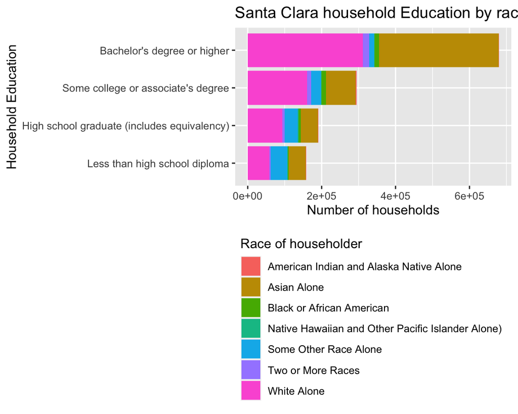

### Filled Plot

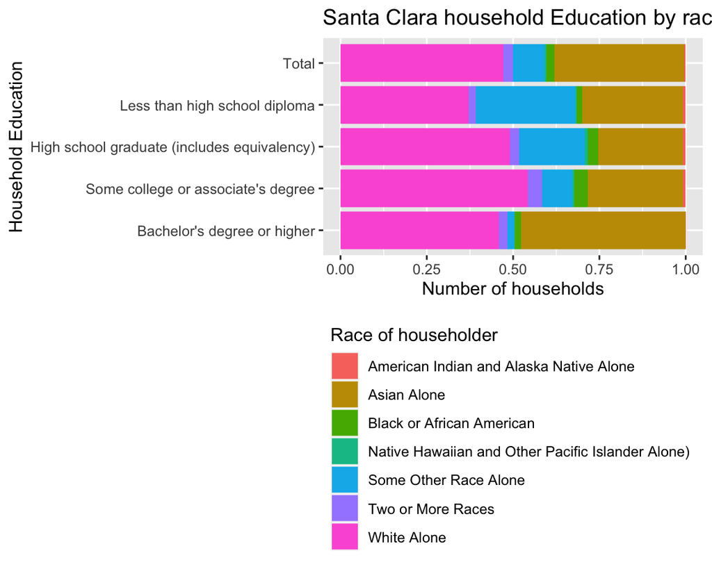

# Question 2

2. An estimate of the number and percentage of K-12 students who have no internet access at home, using the latest available PUMS data. (Note that 2019 1-yr PUMS data will be available in mid-October 2020, so you might choose to update your analysis using that data at that time.) State your assumptions clearly, especially how useful the available data is for understanding the challenges of remote learning in 2020. Include a map of this metric for all PUMAs in the Bay Area.

Interpretation: The areas with the highest percentage of households with K-12 kids with no internet access are around Alameda while the lowest percent of households who have kids with no internet access are around San Francisco and San Jose. Assumptions: We only take into account people who filled out the census. We look at it on the household level rather than an individual level , meaning that a house could have multiple kids with no internet access residing within it, yet that would only count as 1 rather than for each kid. This means that bigger families are less likely to be accurately portrayed. We are assuming kids are K-12 if they are under the age of 17 thus, highschool kids over the age of 17 are not being represented

For a more detailed view into the logic used to derive this plot, please visit https://micpim.github.io/HW2Page.html

### K-12 no internet Map

[interactive chart not shown]

# Question 3

3. A migration analysis, as demonstrated in 2.3, using data on educational attainment. Discuss what you believe can be interpreted from the results of this methodology, especially as it relates to the “educational mobility” of Bay Area residents.

Interpretation: I was rather suprised at this graph, i would have expected that as education levels decreased there would be an increase in migration out of the bay, similar to what we see when we analyze migration based on income levels. However this seemed to only be true in the case of “Some college or associate’s degree” , migration from all other levels of education seemed to increase.

Although the Assumptions: this only takes into account people 25 years of age This only takes into account people who fill out the census

For a more detailed view into the logic used to derive this table, please visit https://micpim.github.io/HW2Page.html

### Migration table based on education

| Education | Internal net | External net | Here last year | Here this year | Outflow | Inflow |
| --- | --- | --- | --- | --- | --- | --- |
| Bachelor’s degree | 5162 | 1012 | 1569338 | 1575512 | 104116 | 105128 |
| Graduate or professional degree | 1395 | 19098 | 1157040 | 1177533 | 77270 | 96368 |
| High school graduate (includes equivalency) | 4701 | 1195 | 878801 | 884697 | 35783 | 36978 |
| Less than high school graduate | 17857 | 1415 | 574248 | 593520 | 21179 | 22594 |
| Some college or associate’s degree | -29849 | -10449 | 1370276 | 1329978 | 64024 | 53575 |